# Spatial Data Objects

Many R packages have been developed to visualize and analyze spatial data. The best comprehensive resource that I’ve found on this topic is the book [Applied Spatial Data Analysis with R](http://www.amazon.com/Applied-Spatial-Data-Analysis-Use/dp/1461476178). This tutorial relies heavily on that book.

- The sp package
- Spatial objects
- SpatialPoints objects
- SpatialPointsDataFrame objects
- Plotting

# The `sp` package and `Spatial*` objects

Object oriented programming provides a framework for storing spatial information, along with information associated with spatial data, in self-contained and stable data objects. These objects can then be easily fed into functions that can vizualize and analyze the contents of the object.

The `sp` package is a foundational package for dealing with spatial data. It provides classes and methods for making S4 objects in R. (For an explanation of S4 objects, see Hadley Wickham’s page on object oriented programming in [Advanced R](http://adv-r.had.co.nz/OO-essentials.html).

## `Spatial`

The most basic object that can be created with the `sp` package is the `Spatial` object. This object just contains information for a boundary box and the coordinate system.

Let’s create a boundary box in the Chicago area. We’ll use the constructor function that has the same name as the class, `Spatial()`. The two arguments are `bbox` and `proj4string`. The `bbox` argument is for the bounding box. It takes a matrix with at least two rows, and the column names must be `min` and `max`. The first row contains the eastings (x-axis, or the longitude) and the second row contains the northings (y-axis, or latitude).

```r
# create a boundary box
longitudes <- c(-88.156775, -87.589771)
latitudes <- c(41.652208, 42.154143)
bounding_box <- matrix(c(longitudes, latitudes), nrow = 2, byrow = TRUE,
                       dimnames = list(NULL, c("min", "max")))
bounding_box
```

```
##            min       max
## [1,] -88.15677 -87.58977
## [2,]  41.65221  42.15414
```

The second argument, `proj4string`, takes a string that specifies which projection the coordinates are in. See the [`proj4` package](https://cran.r-project.org/web/packages/proj4/) for details on which strings to use. The simplest string is “+proj=longlat”.

```r
projection <- "+proj=longlat"
```

Now we can create the `Spatial` object. (The projection string must be wrapped in the `CRS()` function).

```r
library(sp)
chicago_sp <- Spatial(bbox = bounding_box, proj4string = CRS(projection))
chicago_sp
```

```
## An object of class "Spatial"
## Slot "bbox":
##            min       max
## [1,] -88.15677 -87.58977
## [2,]  41.65221  42.15414
##
## Slot "proj4string":
## CRS arguments: +proj=longlat +ellps=WGS84
```

## `SpatialPoints`

A `Spatial` object isn’t much good by itself, but it’s the base object that other sub-classes are built on. To see the list of sub-classes, use the `getClass()` function.

```r
getClass("Spatial")
```

```
## Class "Spatial" [package "sp"]
##
## Slots:
##
## Name:         bbox proj4string
## Class:      matrix         CRS
##
## Known Subclasses:
## Class "SpatialPoints", directly
## Class "SpatialMultiPoints", directly
## Class "SpatialGrid", directly
## Class "SpatialLines", directly
## Class "SpatialPolygons", directly
## Class "SpatialPointsDataFrame", by class "SpatialPoints", distance 2
## Class "SpatialPixels", by class "SpatialPoints", distance 2
## Class "SpatialMultiPointsDataFrame", by class "SpatialMultiPoints", distance 2
## Class "SpatialGridDataFrame", by class "SpatialGrid", distance 2
## Class "SpatialLinesDataFrame", by class "SpatialLines", distance 2
## Class "SpatialPixelsDataFrame", by class "SpatialPoints", distance 3
## Class "SpatialPolygonsDataFrame", by class "SpatialPolygons", distance 2
```

A sub-class is a class whose objects contain all of the information in the parent class, plus additional information. For our purposes, the most useful direct sub-class of `Spatial` is `SpatialPoints`. Typically we will want to look at monitor locations (i.e. points), so we need to represent those as points in a `SpatialPoints` object. We’ll use the `airdata` dataset from the `region5air` package.

```r
library(region5air)
library(dplyr)
data(airdata)
as.tbl(airdata)
```

```
## Source: local data frame [367,595 x 20]
##
##            site data_status action_code           datetime parameter
##           (chr)       (int)       (int)              (chr)     (int)
## 1  840170890005           0          10 20141231T0100-0600     44201
## 2  840170311601           0          10 20141231T0100-0600     44201
## 3  840170314002           0          10 20141231T0100-0600     44201
## 4  840170310001           0          10 20141231T0100-0600     44201
## 5  840171110001           0          10 20141231T0100-0600     44201
## 6  840170971007           0          10 20141231T0100-0600     44201
## 7  840170314201           0          10 20141231T0100-0600     44201
## 8  840170310076           0          10 20141231T0100-0600     44201
## 9  840170313103           0          10 20141231T0100-0600     44201
## 10 840171971011           0          10 20141231T0100-0600     44201
## ..          ...         ...         ...                ...       ...
## Variables not shown: duration (int), frequency (int), value (dbl), unit
##   (int), qc (int), poc (int), lat (dbl), lon (dbl), GISDatum (chr), elev
##   (int), method_code (int), mpc (chr), mpc_value (chr), uncertainty (lgl),
##   qualifiers (chr)
```

Before we can create a `SpatialPoints` object, we need to know what projection the coordinates are in.

```r
unique(airdata$GISDatum)
```

```
## [1] "WGS84" "NAD83"
```

There are two projections, so we will split up the data, then later we will merge them by transforming one projection into another.

```r
air_wgs84 <- filter(airdata, GISDatum == "WGS84")
air_nad83 <- filter(airdata, GISDatum == "NAD83")
```

The `SpatialPoints()` function has the same parameters as the `Spatial` function, except it also takes a matrix of coorinates for points. The matrix must have unique row names, eastings must be in the first column, and northings must be in the second column. Here we create the coordinate matrices.

```r
air_wgs84_monitors <- unique(select(air_wgs84, site, lat, lon))
air_wgs84_coords <- cbind(air_wgs84_monitors$lon, air_wgs84_monitors$lat)
row.names(air_wgs84_coords) <- air_wgs84_monitors$site
head(air_wgs84_coords, 3)
```

```
##                   [,1]     [,2]
## 840170890005 -88.27303 42.04915
## 840170311601 -87.99057 41.66812
## 840170314002 -87.75247 41.85524
```

```r
air_nad83_monitors <- unique(select(air_nad83, site, lat, lon))
air_nad83_coords <- cbind(air_nad83_monitors$lon, air_nad83_monitors$lat)
row.names(air_nad83_coords) <- air_nad83_monitors$site
air_nad83_coords
```

```
##                  [,1]     [,2]
## 840550590025 -87.8860 42.59600
## 840550590019 -87.8093 42.50472
```

Now we specify the projections.

```r
wgs84 <- CRS("+proj=longlat +ellpsWGS84")
nad83 <- CRS("+proj=longlat +ellpsNAD83")
```

When we create the `SpatialPoints` object, if we don’t specify the bounding box it will automatically be created, based on the extreme locations in the coordinate matrix.

```r
air_wgs84_spoints <- SpatialPoints(coords = air_wgs84_coords, proj4string = wgs84)
air_nad83_spoints <- SpatialPoints(coords = air_nad83_coords, proj4string = nad83)
```

We can look at the bounding boxes by using the `bbox()` function.

```r
bbox(air_wgs84_spoints)
```

```
##                 min       max
## coords.x1 -88.27303 -87.02777
## coords.x2  41.22144  42.46757
```

```r
bbox(air_nad83_spoints)
```

```
##                 min      max
## coords.x1 -87.88600 -87.8093
## coords.x2  42.50472  42.5960
```

`spTransform()` will transform a `Spatial*` object from one coordinate reference system (CRS) to another. Here we change the object with the NAD83 projection to WGS84 and recombine with the other `SpatialPoints` object.

```r
# you must have the rgdal package installed
air_spoints <- spTransform(air_nad83_spoints, CRSobj = wgs84)
air_spoints <- rbind(air_spoints, air_wgs84_spoints)
```

Let’s look at the bounding box now.

```r
bbox(air_spoints)
```

```
##                 min       max
## coords.x1 -88.27303 -87.02777
## coords.x2  41.22144  42.59600
```

## `SpatialPointsDataFrame`

In many cases, you will not just want to plot locations of monitors on a map, but you will want to have data associated with each point. The `SpatialPointsDataFrame` object contains all of the information that a `SpatialPoints` object has, but it also contains a data frame of values associated with the coordinate points.

The way the spatial points and the data frames are connected is by row names. For example, if the the row name is “A” for monitor “1”, then the row name in the data frame must be “A” for records that contain information about that monitor.

```r
monitor_locations <- cbind(1:5, 1:5)
row.names(monitor_locations) <- LETTERS[1:5]
monitor_locations
```

```
##   [,1] [,2]
## A    1    1
## B    2    2
## C    3    3
## D    4    4
## E    5    5
```

```r
monitor_info <- data.frame(monitor = paste0("monitor", 1:5),
                           pollutant = c(rep("o3", 3), rep("pm2.5", 2)),
                           row.names = LETTERS[1:5])
monitor_info
```

```
##    monitor pollutant
## A monitor1        o3
## B monitor2        o3
## C monitor3        o3
## D monitor4     pm2.5
## E monitor5     pm2.5
```

When we use `SpatialPointsDataFrame()` we feed it the points matrix, the data frame, we specify the projection, and we set `match.ID = TRUE`.

```r
my_spdf <- SpatialPointsDataFrame(monitor_locations, monitor_info,
                                  proj4string = CRS("+proj=longlat"),
                                  match.ID = TRUE)
my_spdf
```

```
##   coordinates  monitor pollutant
## A      (1, 1) monitor1        o3
## B      (2, 2) monitor2        o3
## C      (3, 3) monitor3        o3
## D      (4, 4) monitor4     pm2.5
## E      (5, 5) monitor5     pm2.5
```

Since we have already created a `SpatialPoints` object from the monitors in `airdata`, we can use that as our monitor matrix. The row names of that object are actually the monitor site codes.

```r
head(air_spoints, 3)
```

```
## SpatialPoints:
##              coords.x1 coords.x2
## 840550590025 -87.88600  42.59600
## 840550590019 -87.80930  42.50472
## 840170890005 -88.27303  42.04915
## Coordinate Reference System (CRS) arguments: +proj=longlat
## +ellps=WGS84
```

So we can create a data frame with information about each monitor in `airdata`, give row names to that data frame that correspond to the `SpatialPoints` object, then create the `SpatialPointsDataFrame` object.

```r
# select a few columns with useful information
airdata$parameter <- factor(airdata$parameter, levels = c(44201, 88101, 62101),
                            labels = c("ozone", "pm2.5", "temp"))
air_monitors_df <- unique(airdata[, c("site", "parameter")])
air_monitors_df$value <- "yes"
head(air_monitors_df, 3)
```

```
##           site parameter value
## 1 840170890005     ozone   yes
## 2 840170311601     ozone   yes
## 3 840170314002     ozone   yes
```

```r
library(tidyr)
air_monitors_df <- spread(air_monitors_df, parameter, value, fill = "no")
row.names(air_monitors_df) <- air_monitors_df$site
head(air_monitors_df, 3)
```

```
##                      site ozone pm2.5 temp
## 840170310001 840170310001   yes    no   no
## 840170310032 840170310032   yes    no   no
## 840170310064 840170310064   yes    no   no
```

```r
air_spdf <- SpatialPointsDataFrame(air_spoints, air_monitors_df,
                                   proj4string = wgs84, match.ID = TRUE)
head(air_spdf, 3)
```

```
##                        coordinates         site ozone pm2.5 temp
## 840170310001     (-87.886, 42.596) 840170310001   yes    no   no
## 840170310032  (-87.8093, 42.50472) 840170310032   yes    no   no
## 840170310064 (-88.27303, 42.04915) 840170310064   yes    no   no
```

# Plotting

Plotting `Spatial*` objects is relatively easy. Methods have been created for most plotting functions in R.

Here, we plot the `SpatialPoints` object we created, using the monitors in `airdata`.

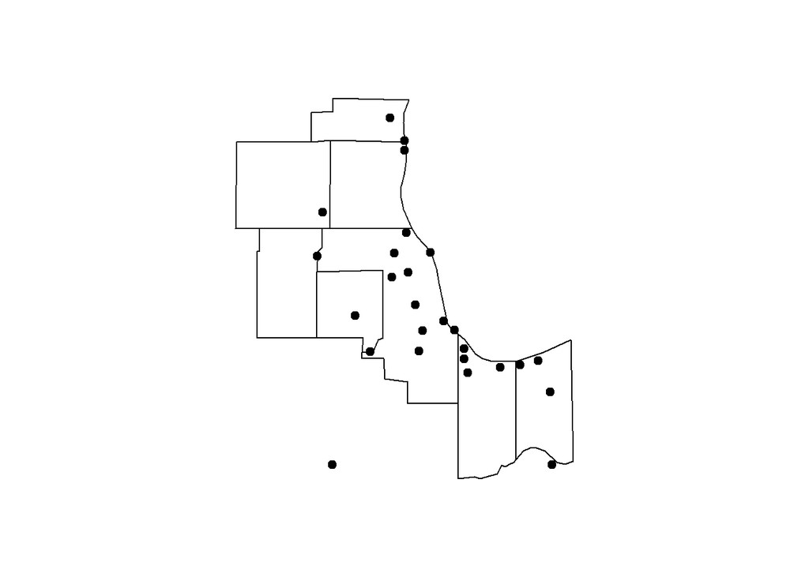

```r
library(maps)
m <- map(database = 'county', regions = c('illinois,cook', 'illinois,lake', 'illinois,du page',
                                     'illinois,kane', 'illinois,mchenry', 'indiana,lake',
                                    'indiana,porter',  'wisconsin,kenosha'))
plot(air_spoints, pch = 19, add = TRUE)
```

We can subset the `SpatialPointsDataFrame` to just plot the monitors that measure ozone.

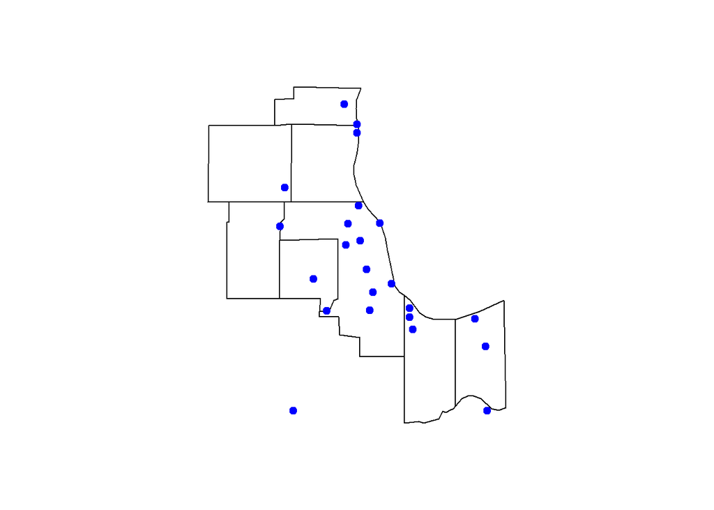

```r
map(m)
plot(air_spdf[air_spdf$ozone == "yes", ], pch = 19, col = "blue", add = TRUE)
```

Then we can add PM2.5 monitors to the map, using a different color to distinguish the two pollutants.

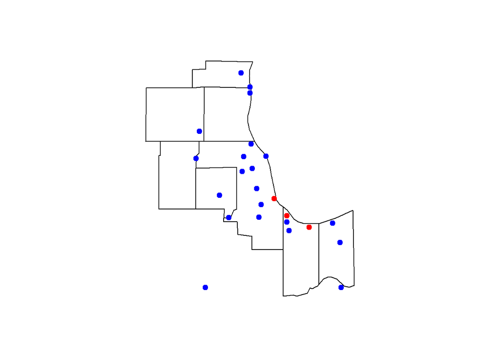

```r
plot(air_spdf[air_spdf$pm2.5 == "yes", ], pch = 19, col = "red", add = TRUE)
```

# Further Reading

This tutorial is a minimal introduction to the spatial data objects in R. Below is a list of resources for learning more about what you can do with R and geographic data.

- For a good introduction to using GIS data in R, see [this vignette](https://cran.r-project.org/doc/contrib/intro-spatial-rl.pdf).
- For a comprehensive overview of spatial data and analysis in R, see [Applied Spatial Data Analysis with R](http://www.amazon.com/Applied-Spatial-Data-Analysis-Use/dp/1461476178).
- The [CRAN Task View on Analysis of Spatial Data](https://cran.r-project.org/web/views/Spatial.html) should be a comprehensive list of R packages on CRAN that can be used for spatial analysis.

# Exercises

Go to the [exercises page](http://rpubs.com/NateByers/spatialexercises) for this tutorial and test your comprehension of this material.